# 최대 손실 낙폭

MDD = (최저점 - 최고점) / 최고점  
특정 기간 동안 얼마큼의 최대 손실이 날 수 있는지를 나타낸다.  
퀀트 투자에서는 수익률을 높이는 것보다 MDD를 낮추는 것이 더 낫다로 할 만큼 중요한 지표다.

|  | 종가 | 대비 | 등락률 | 시가 | 고가 | 저가 | 거래량 | 거래대금 | 시가총액 | 상장주식수 |
| --- | --- | --- | --- | --- | --- | --- | --- | --- | --- | --- |
| 2014-12-01 | 1185.0 | -190.0 | -13.82 | 1375.0 | 1375.0 | 1170.0 | 5468407.0 | 6.656080e+09 | 1.937910e+11 | 163536685.0 |
| 2014-11-28 | 1375.0 | -20.0 | -1.43 | 1405.0 | 1420.0 | 1360.0 | 1152188.0 | 1.590045e+09 | 2.248629e+11 | 163536685.0 |
| 2014-11-27 | 1395.0 | 30.0 | 2.20 | 1370.0 | 1425.0 | 1350.0 | 2182764.0 | 3.041324e+09 | 2.281337e+11 | 163536685.0 |
| 2014-11-26 | 1365.0 | -35.0 | -2.50 | 1405.0 | 1425.0 | 1360.0 | 1795728.0 | 2.483437e+09 | 2.232276e+11 | 163536685.0 |
| 2014-11-25 | 1400.0 | 5.0 | 0.36 | 1390.0 | 1410.0 | 1370.0 | 1564902.0 | 2.180691e+09 | 2.289514e+11 | 163536685.0 |
| ... | ... | ... | ... | ... | ... | ... | ... | ... | ... | ... |
| 2000-01-11 | 12500.0 | -200.0 | -1.57 | 12400.0 | 13000.0 | 12400.0 | 56760.0 | 7.190995e+08 | 2.000000e+11 | 16000000.0 |
| 2000-01-10 | 12700.0 | -50.0 | -0.39 | 13000.0 | 13400.0 | 12300.0 | 56770.0 | 7.344470e+08 | 2.032000e+11 | 16000000.0 |
| 2000-01-07 | 12750.0 | 150.0 | 1.19 | 12600.0 | 13400.0 | 12500.0 | 68960.0 | 8.927895e+08 | 2.040000e+11 | 16000000.0 |
| 2000-01-06 | 12600.0 | -1100.0 | -8.03 | 14250.0 | 14250.0 | 12400.0 | 86740.0 | 1.131856e+09 | 2.016000e+11 | 16000000.0 |
| 2000-01-05 | 13700.0 | -800.0 | -5.52 | 13800.0 | 14200.0 | 13150.0 | 67140.0 | 9.074730e+08 | 2.192000e+11 | 16000000.0 |

3688 rows × 10 columns

오늘 살펴볼 종목은 대한전선이다.  
급격한 상승을 지켜내지 못하고 크게 하락한 대표적인 종목이다.  
당시 급격히 상승한 부채 비율과 경영진의 부도덕으로 인해 회사가 망가진 안타까운 케이스이다.

# 주가 흐름

```
최대값: 90000.0
최솟값 : 1185.0
```

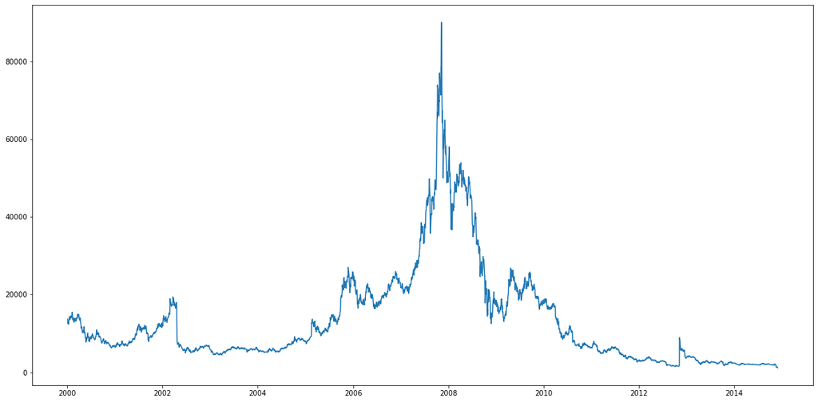

주가는 다음과 같다. 2008년도 즈음에 최고가를 찍고 계속해서 하락하는 모습이다.  
위 주식 데이터를 활용해서 MDD를 나타내보자

# MDD

여기서는 기준일을 180일로 정한다. 즉, 180일 동안의 최고점과 최저점으로 계산을 해서 MDD를 나타낸다.

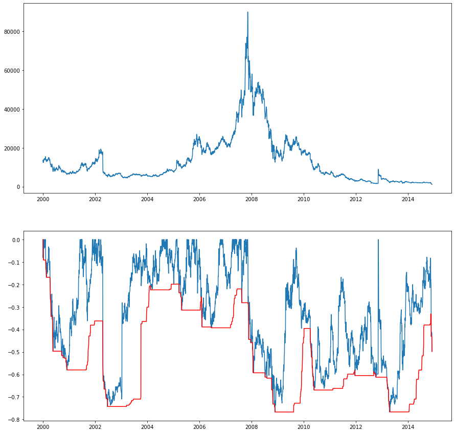

변동성이 큰 주식인 만큼 MDD 값 또한 크게 나온다.  
MDD 가 0.0에 닿았다는 뜻은 설정한 기준일(180일) 중 최고가를 달성했다는 뜻이다.  
반대로 MDD가 -1.0 값에 가깝다는 것은 그만큼 주가가 하락했다는 뜻이다.  
예를 들어 2009년도 쯤에 대한전선에 투자할지 고려해 본다면 최근 180일 동안 최대 낙폭이 약 75% 즉 100만원이 25만원이 된 전적이 있다는 뜻이 된다.  
변동성이 너무 커서 투자할 엄두를 내기가 쉽지 않다.  
자 그럼 큰 기업들은 어떨까??

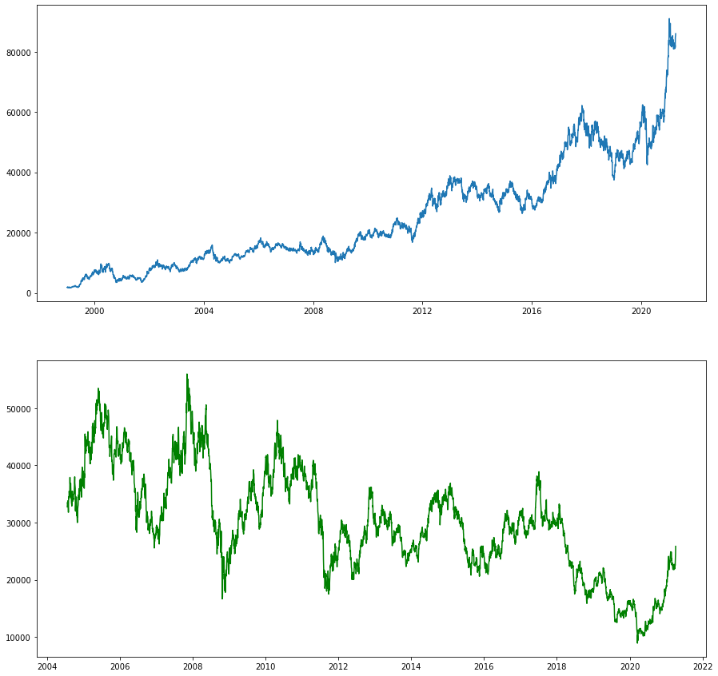

대표적인 우상향 기업과 우하향 기업이다.  
둘다 글쓴이가 주주로 있는 회사인데 그래프만 보면 아래쪽은 정리해야 하는것 아닌가 싶다.  
하지만 투자는 가치를 보고 하는 것이기에...

아무튼 이 둘 회사의 MDD를 한번 그려보자

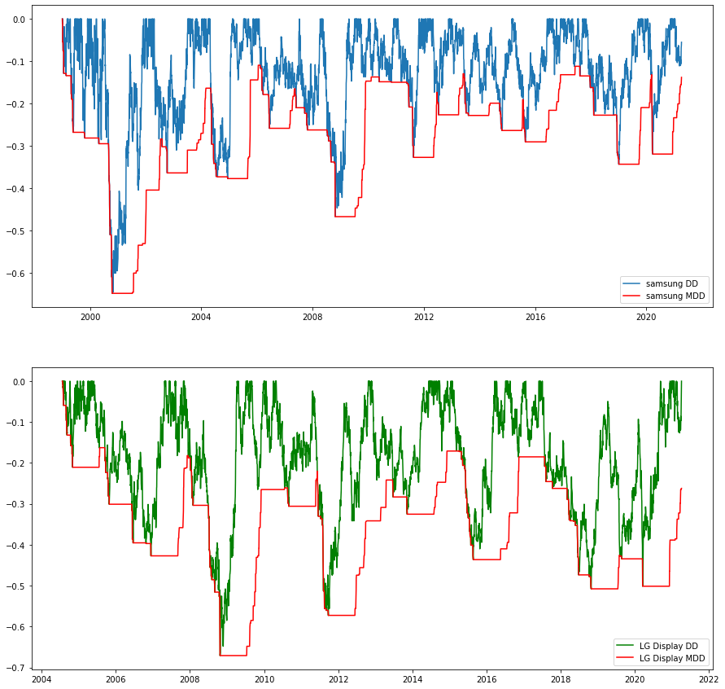

음.. 대한 전선에 비교하면 역시 MDD 값이 괜찮을 것으로 보인다. 하지만 대기업이라고 50% 이상의 폭락기간이 없다고는 말할 수 없을 것 같다.  
2008년 이후 2010년 사이에는 삼성전자와 LG디스플레이 모두 큰 값의 MDD 즉, 큰 폭락기간을 동시에 맞이했다. 이는 회사의 이유라기 보다는 주식 시장의 변동이라고 볼 수도 있을 것이다. 다 아는 바와 같이 이 기간은 미국 발 경제위기, 서브프라임모기지 사태 때이다.

MDD가 주식시장에서 중요한 지표라고 하지만 MDD만으로는 어떤 지표와 마찬가지로 확신을 가진 판단을 하기는 힘들다.